# Beijing: simulated road flow on day 10

## Source and measurement

The source is simulation day 10 from `output_LinkTDMOE.csv`, identified in *个体轨迹数据拥堵溯源分析项目及数据说明.docx*. The included geometry covers 11,742 of the source’s 12,287 directed node pairs. The cache retains all 1,440 minute records for all 12,287 source pairs. Preparation joins their directed node pair IDs to the supplied geometry and excludes the 545 pairs without geometry, without spatial resampling.

`link_volume_in_veh_per_hour_for_all_lanes` is an all-lane hourly entry-flow rate reported each minute. Five consecutive rates are averaged to form each five-minute value, still in vehicles/hour. This equals twelve times the entry count in those five minutes. It is neither relative load nor a field detector measurement. The source CSV identity and checksum accompany the cache.

## Data preparation

`data/source.rds` contains the selected source-level records and supplied geometry. `prepare.R` converts them to the common input without downloading data. Its executed implementation appears in Appendix A. The generated `data/input.rds` is then read by the common package.

```r
library(bdynets)
source("prepare.R")
prepared_file <- prepare_example(".")
x <- read_traffic(prepared_file)
input <- readRDS(prepared_file)
index <- match(params$time_label,sub("^.* ","",x$time_labels))
stopifnot(!is.na(index))
```

The map starts at 08:00 and covers 5 minutes. The default 08:00 is a demonstration selection, not a maximum-based selection. Numeric seconds and displayed labels retain the supplied source clock; they do not establish a UTC offset.

```r
knitr::kable(data.frame(
  Item=c("Roads","Frames","First interval start","Last interval start","Flow unit"),
  Value=c(nrow(x$roads),length(x$times),x$time_labels[1],tail(x$time_labels,1),x$unit)),
  caption="Data scope")
```

Data scope

| Item | Value |
| --- | --- |
| Roads | 11742 |
| Frames | 288 |
| First interval start | 00:00 |
| Last interval start | 23:55 |
| Flow unit | vehicles/hour |

| Common field | Meaning |
| --- | --- |
| road_id | Unique directed road or segment identifier |
| geometry | Longitude/latitude vertex matrix, ordered in travel direction |
| time | Source-clock interval start in numeric seconds |
| flow | Supplied nonnegative measurement; zero is observed and NA is missing |
| unit | Supplied measurement label, without inferred conversion |

```r
knitr::kable(head(input$flow),caption="Actual prepared flow records")
```

Actual prepared flow records

| road_id | time | flow |
| --- | --- | --- |
| 4 | 0 | 0 |
| 5 | 0 | 0 |
| 6 | 0 | 0 |
| 7 | 0 | 0 |
| 8 | 0 | 0 |
| 9 | 0 | 0 |

## Whole-day coverage

```r
knitr::kable(data.frame(
  Statistic=c("Expected road-time cells","Observed cells","Missing cells","Observed zero cells"),
  Value=c(length(x$values),sum(!is.na(x$values)),sum(is.na(x$values)),sum(x$values==0,na.rm=TRUE))),
  caption="All supplied roads and intervals")
```

All supplied roads and intervals

| Statistic | Value |
| --- | --- |
| Expected road-time cells | 3381696 |
| Observed cells | 3381696 |
| Missing cells | 0 |
| Observed zero cells | 1978863 |

A road-time cell is one road in one interval. These counts cover the whole day, including roads outside the central-area map view. An omitted pair and an explicit NA are missing; neither is replaced by zero.

## Selected-time map and statistics

[figure not shown]

Simulated all-lane hourly entry rates at the selected five-minute interval. The map uses a central-area view; statistics include all supplied roads.

```r
plot(x,index=index)
```

Green through red denotes lower through higher flow on the full-day log1p scale; gray denotes missing observations. High flow alone does not establish low speed or a cause of congestion. Basemap roads without observations provide context.

```r
selected <- traffic_summary(x,index=index)
knitr::kable(selected[c("time","roads","available","missing","zero")],
  caption="Selected-interval availability")
```

Selected-interval availability

| time | roads | available | missing | zero |
| --- | --- | --- | --- | --- |
| 08:00 | 11742 | 11742 | 0 | 4429 |

```r
knitr::kable(selected[c("minimum","median","mean","p95","maximum")],
  digits=2,caption=paste("Selected-interval distribution [",x$unit,"]"))
```

Selected-interval distribution [ vehicles/hour ]

| minimum | median | mean | p95 | maximum |
| --- | --- | --- | --- | --- |
| 0 | 48 | 238.93 | 1104 | 4548 |

At 08:00, the available-road mean is 238.93 vehicles/hour and the median is 48; 4,429 roads have recorded zero. These numbers describe this interval, not the whole day and not distinct vehicles across the network.

## Daily pattern and limits

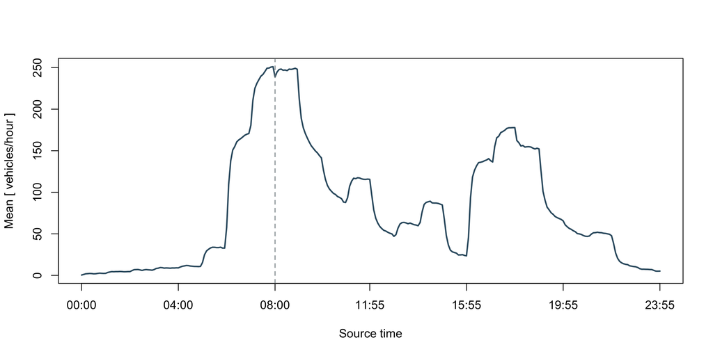

Mean of available road values in each interval. The dashed line marks the selected map time.

```r
trend <- traffic_trend(x)
plot(trend$time,trend$mean,type="l",lwd=2,col="#365c70",xaxt="n",
     xlab="Source time",ylab=paste("Mean [",x$unit,"]"))
at <- unique(round(seq(1,nrow(trend),length.out=7)))
axis(1,at=trend$time[at],labels=sub("^.* ","",trend$label[at]))
abline(v=x$times[index],lty=2,col="#7b858b")
```

```r
peak <- which.max(trend$mean)
```

The largest included-road mean is 251.1 vehicles/hour at 07:55. The curve includes recorded zeros and excludes missing values. All 3,381,696 included road-frame cells are present. This completeness does not cover the 545 source pairs without supplied geometry. Lane counts and simulation conditions differ between roads. No event records are supplied.

## Figure and data export

The common `traffic_export()` interface writes PNG/PDF maps and applicable trends, exact selected records, summary and trend tables, source metadata, input/output MD5 checksums and session information. `selected-frame.rds` retains the full input’s color thresholds and unit for inspection; it is not a new input bundle. Existing output directories are refused. The report parameter `export` defaults to false, so normal rendering creates no export folder.

```r
if(params$export) {
  label <- gsub("[^[:alnum:]_-]+","-",x$time_labels[index])
  traffic_export(x,file.path(params$export_dir,label),index=index,
    input_files=c(source="data/source.rds",prepared="data/input.rds"))
}
```

## Basemap source

The figures use the supplied offline OSM-derived context. Basemap build dates identify the context snapshot, independently of the traffic date or simulation day. Generalized map features are suitable for display, not a routable road graph. Map data © [OpenStreetMap contributors](https://www.openstreetmap.org/copyright); basemap extraction uses Protomaps archives distributed as ODbL Produced Works.

| Item | Value |
| --- | --- |
| Region | Supplied context |
| Archive URL | https://build.protomaps.com/20261020.pmtiles |
| Build date | 2026-10-20 |
| Retrieved UTC | 2026-10-22T08:35:59.892482+00:00 |
| Zoom | 11 |
| Recorded bounds (south, west, north, east) | 39.59570, 116.37468, 39.88456, 116.86034 |
| License | OSM-derived Protomaps basemap, ODbL Produced Work |

The source cache preserves the original tile records and geometry checksums. The cache MD5 below identifies the actual bundled copy used for this report.

## Appendix A: preparation implementation

The following code is the source-to-input transformation executed from `prepare.R`. The input cache supplies all objects used by this function.

```r
prepare_example <- function(base=".", source_file="data/source.rds", output_file="data/input.rds") {
  base <- normalizePath(base, mustWork=TRUE)
  source_path <- file.path(base, source_file)
  s <- readRDS(source_path)
  stopifnot(identical(s$schema, "beijing-native-minute-v1"), s$day_no == 10,
            identical(s$minute, 0:1439), ncol(s$minute_rates) == 1440L,
            all(is.finite(s$minute_rates)), all(s$minute_rates >= 0))
  roads <- s$roads
  roads$road_id <- as.character(roads$edge_index)
  stopifnot(nrow(s$minute_rates) == length(s$road_pairs), !anyDuplicated(s$road_pairs))
  source_row <- match(roads$edge_id, s$road_pairs)
  stopifnot(!anyNA(source_row))
  aligned <- s$minute_rates[source_row, , drop=FALSE]
  starts <- seq.int(1L, 1440L, by=5L)
  rates <- Reduce(`+`, lapply(0:4, function(k) aligned[, starts+k, drop=FALSE])) / 5
  s$settings$times <- s$settings$times[1] + (starts-1L)*60
  s$settings$interval_seconds <- rep(300, length(starts))
  flow <- data.frame(road_id=rep(roads$road_id, ncol(rates)),
    time=rep(s$settings$times, each=nrow(roads)), flow=as.vector(rates))
  events <- NULL
  s$settings$provenance$preparation_check <- list(native_records=length(s$minute_rates), retained_minute_records=length(aligned),
    excluded_source_pairs=length(s$road_pairs)-nrow(roads), samples_per_frame=5L, complete_frames=length(starts), missing_native_values=0L)
  input <- c(list(schema="trafficmap-input-v1", roads=roads, flow=flow, events=events), s$settings)
  input$provenance$source_cache <- list(file=basename(source_file),
    bytes=unname(file.info(source_path)$size), md5=unname(tools::md5sum(source_path)), schema=s$schema)
  stopifnot(!anyDuplicated(roads$road_id), all(flow$road_id %in% roads$road_id),
            !anyDuplicated(flow[c("road_id", "time")]),
            all(is.na(flow$flow) | (is.finite(flow$flow) & flow$flow >= 0)))
  bdynets::traffic_data(roads=roads, flow=flow, events=events,
    times=input$times, time_labels=input$time_labels, interval_seconds=input$interval_seconds,
    unit=if(is.null(input$unit)) "unit unspecified" else input$unit,
    basemap=input$basemap)
  output <- file.path(base, output_file)
  dir.create(dirname(output), recursive=TRUE, showWarnings=FALSE)
  saveRDS(input, output, compress="xz", version=3)
  invisible(output)
}
if(sys.nframe()==0L) {
  script <- sub("^--file=", "", grep("^--file=", commandArgs(FALSE), value=TRUE))
  if(length(script)!=1L) stop("Rscript entrypoint is required")
  if(!file.exists(script)) script <- gsub("~+~", " ", script, fixed=TRUE)
  prepare_example(dirname(normalizePath(script, mustWork=TRUE)))
  cat("Prepared data/input.rds\n")
}
```

## Appendix B: verification and runtime

```r
knitr::kable(data.frame(Check=names(input$provenance$preparation_check),
  Value=unlist(input$provenance$preparation_check)),caption="Executed preparation checks")
```

Executed preparation checks

|  | Check | Value |
| --- | --- | --- |
| native_records | native_records | 17693280 |
| retained_minute_records | retained_minute_records | 16908480 |
| excluded_source_pairs | excluded_source_pairs | 545 |
| samples_per_frame | samples_per_frame | 5 |
| complete_frames | complete_frames | 288 |
| missing_native_values | missing_native_values | 0 |

```r
knitr::kable(data.frame(File=c("source.rds","input.rds"),
  Bytes=unname(file.info(c("data/source.rds","data/input.rds"))$size),
  MD5=unname(tools::md5sum(c("data/source.rds","data/input.rds")))),
  caption="Actual bundled files")
```

Actual bundled files

| File | Bytes | MD5 |
| --- | --- | --- |
| source.rds | 5184272 | 364d6fa135134062f4c21eac72ac94ff |
| input.rds | 2281224 | d63a45422cf2d9540886cc678591bbf8 |

[session information not shown]